# Text Mining

Hamza Saadi

September 21, 2018

We need to relaod the libraries and the data:

```r
library(tidyverse) #data manipulation and visualization
library(textmineR)
library(wordcloud)
library(SentimentAnalysis)

DF <- read.csv("CleanedArticles.csv",                  # Read CSV file with "Latin1" Encoding
               encoding = "latin1",                    # also we specified the class of each Column
               colClasses = c("character","Date",rep("character",3)),# using attr colClasses
               stringsAsFactors=F)                     # and set StringsAsFactors to False

glimpse(DF)                                            # take a glimpse to see
```

```
## Observations: 1,052
## Variables: 5
## $ Title            <chr> "Suivi des chantiers immobiliers par satellit...
## $ Publication.Date <date> 2018-07-27, 2018-07-23, 2018-07-21, 2018-07-...
## $ Writer           <chr> "Rédaction Lkeria", "Rédaction Lkeria", "Lotf...
## $ Full.Text        <chr> "En orbite depuis septembre 2016 le satellite...
## $ Type             <chr> "logement", "immobilier", "transaction", "aad...
```

Before starting let’s how many articles do we have over time.

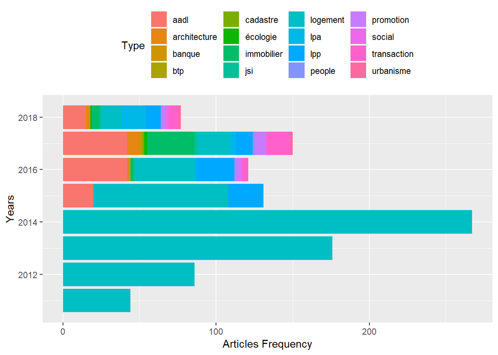

```r
DF <- DF %>%
  mutate(Year = as.integer(format(Publication.Date,"%Y")),      #Creat new Variable Year
         n_char = nchar(Full.Text))                             # Creat new variabl character length

ggplot(DF, aes(Year))+
  geom_bar(aes(fill = Type), position = position_stack(reverse = TRUE)) +
  coord_flip() +
  theme(legend.position = "top")+
  xlab( "Years" ) +
  ylab( "Articles Frequency" )
```

As we can see that Lkeria start make classification for articles only after year 2014.

What about the lentgh of documents?

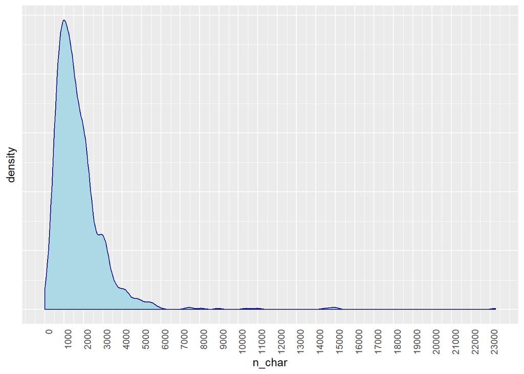

```r
ggplot(DF, aes(x=n_char))+
  geom_density(color="darkblue", fill="lightblue") +
  theme(axis.text.y = element_blank(),
  axis.ticks = element_blank(),
  axis.text.x = element_text(angle = 90, hjust = 1))+
  scale_x_continuous(breaks = round(seq(0, max(DF$n_char), by = 1000),1))
```

Not let’s focuse on more important things, Documents clustering.  
Since we’re going to study only subject “Housing”, so we’re going to select only articles of types:

- `AADL` & `LPA` (both have almost same characteristics)
- `LPP`

```r
AADL_LPA <- DF %>%
  filter(Type %in% c("aadl","lpa"))%>%                  # Select AADL, LPA TYPE
  select(Title,Publication.Date,Writer,Type,Full.Text)  # Select the wanted columns

LPP <- DF %>%
  filter(Type == "lpp")%>%                              # Select AADL, LPP TYPE
  select(Title,Publication.Date,Writer,Full.Text)       # Select the wanted columns

glimpse(AADL_LPA)
```

```
## Observations: 139
## Variables: 5
## $ Title            <chr> "Un symposium sur l'assurance Takaful", "les ...
## $ Publication.Date <date> 2018-07-19, 2018-07-18, 2018-07-17, 2018-07-...
## $ Writer           <chr> "Idir Zidane", "Nabil Walid", "Lotfi Ramdani"...
## $ Type             <chr> "aadl", "aadl", "aadl", "aadl", "aadl", "lpa"...
## $ Full.Text        <chr> "En plus de traiter de la finance islamique l...
```

Before starting clustering and messing up things, let’s see the definition.